**Best game by category**

#TidyTuesday (2022, w4) | Data: BoardGameGeek (via Kaggle) | Graph by @irg_bio

**Category**

**Number of games**

**Distribution of scores**

**Best game**

**Score**

**Year of publication**

**Players**

**Playing time**

**Image**

Fantasy

2681

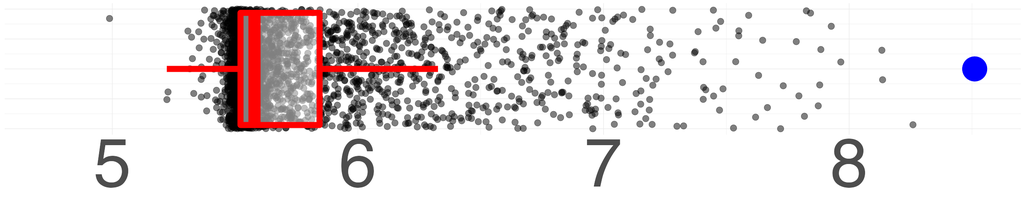

Gloomhaven

8.511

2017

1-4

120

Economic

1503

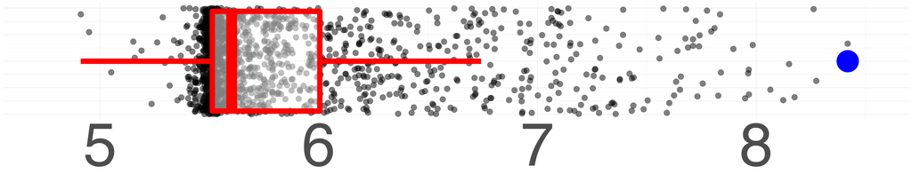

Brass: Birmingham

8.418

2018

2-4

120

[figure not shown]

Science Fiction

1666

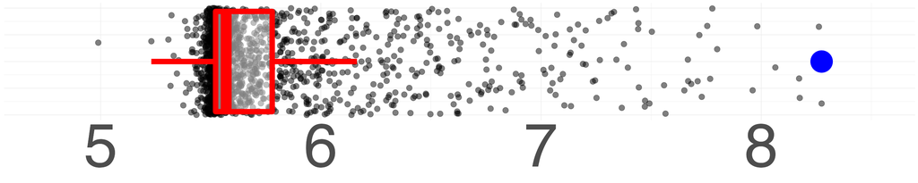

Terraforming Mars

8.274

2016

1-5

120

[figure not shown]

Wargame

3820

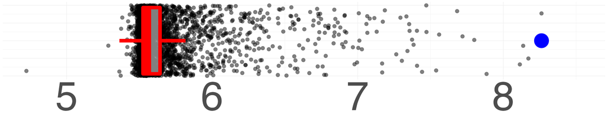

Twilight Imperium: Fourth Edition

8.262

2017

3-6

480

Card Game

6402

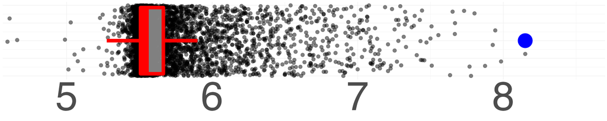

Through the Ages: A New Story of Civilization

8.150

2015

2-4

120

[figure not shown]

Animals

1354

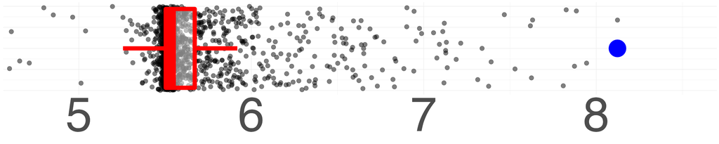

Great Western Trail

8.123

2016

2-4

150

Dice

1847

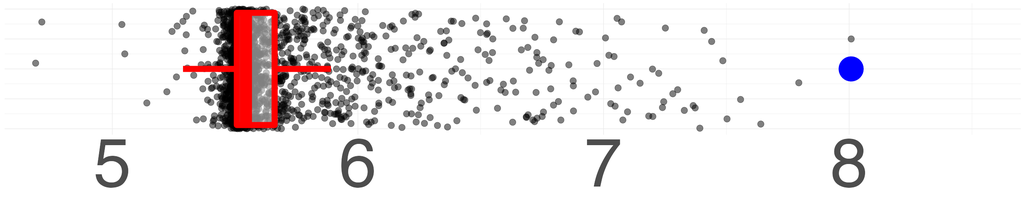

The Castles of Burgundy

8.008

2011

2-4

90

Abstract Strategy

1545

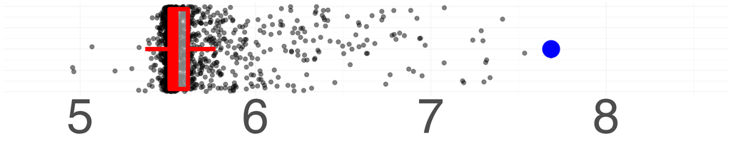

Azul

7.686

2017

2-4

45

[figure not shown]

Bluffing

1206

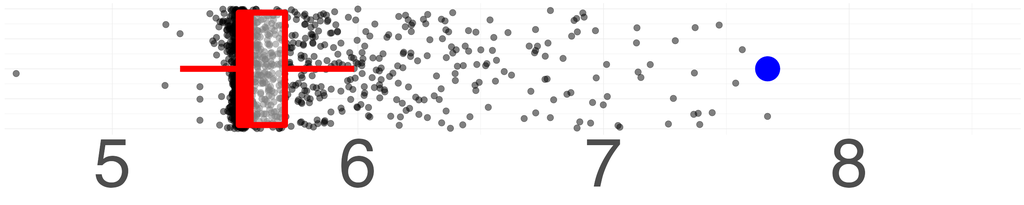

Android: Netrunner

7.668

2012

2

45

Deduction

1150

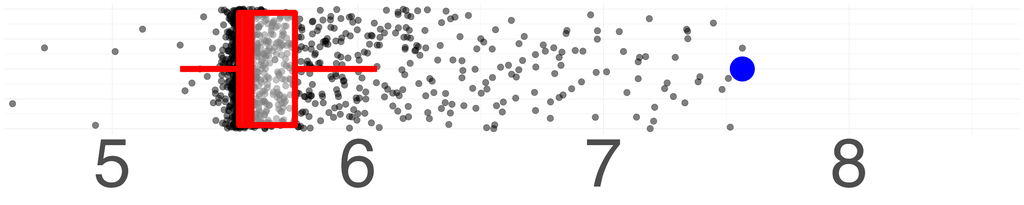

Battlestar Galactica: The Board Game

7.565

2008

3-6

180

Party Game

1968

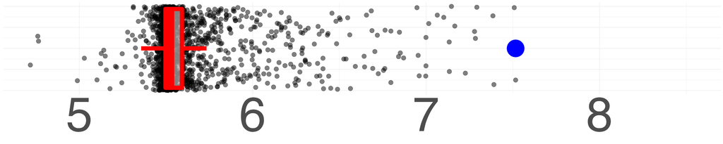

Decrypto

7.516

2018

3-8

45

World War II

1212

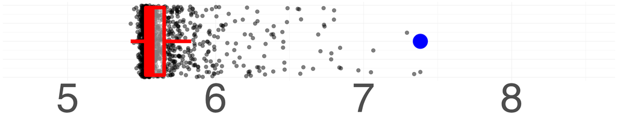

Memoir '44

7.383

2004

2-8

60

Humor

1204

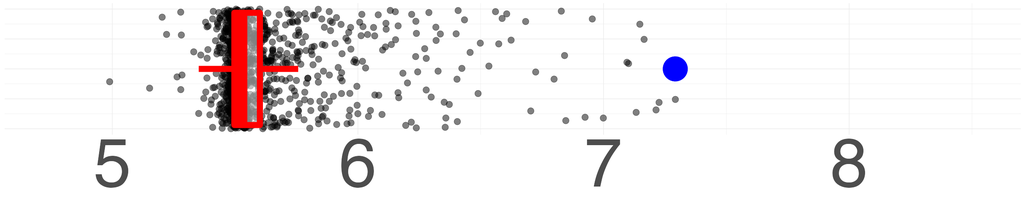

Secret Hitler

7.292

2016

5-10

45

Children's Game

1635

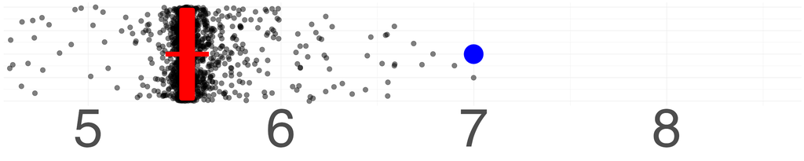

PitchCar

6.999

1995

2-8

30

[figure not shown]